# HW3 Q2 - b03705027 鄭從德

## (1)

```r
load(file="msong_slhw.rdata")
#defin the summary statistic function
sumds = function(ds) {
  nvariable = ncol(ds)
  varnames = colnames(ds)
  for(i in 1:nvariable) {
    tmp1 = ds[,i]
    #remove NA
    tmp1 = tmp1[!is.na(tmp1)]
    n = length(tmp1)
    mean = mean(tmp1)
    median = median(tmp1)
    sd = sd(tmp1)
    q13 = quantile(tmp1, c(0.25, 0.75))
    min1 = min(tmp1)
    max1 = max(tmp1)
    arow = c(n, mean, median, sd, q13, min1, max1)
    if(i==1) {
      out1 = arow
    } else {
      out1 = rbind(out1, arow)
    }
  }
  rownames(out1) = varnames
  colnames(out1) = c("n", "mean", "median", "sd", "Q1", "Q3", "Min", "Max")
  return(out1)
}
#sumds(msong_train)
```

```r
#sumds(msong_test)
```

## Problem (2): Standardize data and Ridge Regression

### Data Preprocess

```r
msong_train_new = head(msong_train, 5000)
# scaled.msong_train = scale(x=msong_train_new)

# Save mean and sd from msong_train
scaled.msong_test = msong_test
nvariable = ncol(msong_train_new)

# standardize features of msong_test(saved as sacled.msong_test)
for(i in 1:nvariable) {
  colm = msong_train_new[,i]
  m = mean(colm)
  s = sd(colm)
  if(i==1){
    # Don't scale y
    scaled.msong_test[,i] = (scaled.msong_test[,i]-m)
  }
  else{
    scaled.msong_test[,i] = ((scaled.msong_test[,i]-m) / s)
  }
}
scaled.msong_test = na.omit(scaled.msong_test)
```

#### Training Part

```r
x_train = msong_train_new[,-1]
x_train = scale(x_train)
y_train = msong_train_new[,1]
y_train = scale(y_train, scale=FALSE)

x_test = scaled.msong_test[,-1]
y_test = scaled.msong_test[,1]

train_and_test = function(x_train, y_train, x_test, y_test, lambda){
  M = ncol(x_train)
  I = diag(M)
  w = solve((t(x_train)%*%x_train)+lambda*I) %*% t(x_train) %*% y_train
  # Predict y_train
  pred = x_train%*%w
  training_error = RMSE(pred, y_train)
  # Predict y_test
  pred = as.matrix(x_test)%*%w
  testing_error = RMSE(pred, y_test)

  return(list(training_error=training_error, testing_error=testing_error))
}

#result = train_and_test(x_train,y_train,x_test,y_test,lambda=5)

RMSE = function(pred, ans){
  return(sqrt(mean((pred - ans)^2)))
}

lambda_list = c(1,10,100,1000,10000)
training_error_list = c()
testing_error_list = c()
for(l in lambda_list){
  result = train_and_test(x_train,y_train,x_test,y_test,lambda=l)
  training_error_list = append(training_error_list, result$training_error)
  testing_error_list = append(testing_error_list, result$testing_error)
}
```

### Plot function

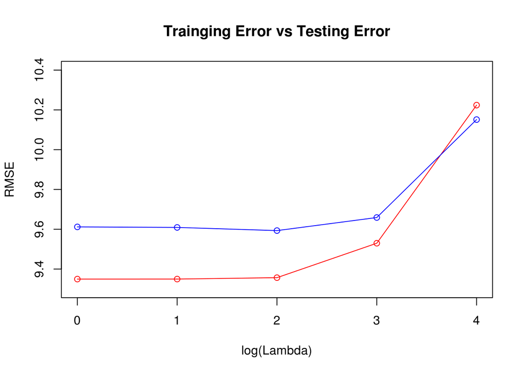

```r
myPlot = function(training_error, testing_error, title, xLabel, xLabel_array, ylim){
  plot(y=training_error, x=xLabel_array ,type = "o",col = "red", xlab = xLabel, ylab = "RMSE",
       main = title, ylim=ylim)
  lines(y=testing_error,x=xLabel_array, type = "o", col = "blue")
}

myPlot(training_error_list,testing_error_list,'Trainging Error vs Testing Error','log(Lambda)',
       log10(lambda_list),c(9.3,10.4))
```

### Insights

可以看出來，在標準化過的資料上，當我取lambda = 100時會得到最低的Testing Error。這個時候Training Error不是最低，表示我們有效的避免了Overfit的情況。後面更大個Lambda造成RMSE爆升，是因為對這樣的X矩陣而言lambda數值已經太高，不再只是調和用的調整參數，而是已經dominate全部的結果。

## Problem (3)

```r
# Get new training data of first 500 and 1000 row
msong_train_500 = head(msong_train, 500)
x_train_500 = scale(msong_train_500[,-1])
y_train_500 = scale(msong_train_500[,1], scale = FALSE)

msong_train_1000 = head(msong_train, 1000)
x_train_1000 = scale(msong_train_1000[,-1])
y_train_1000 = scale(msong_train_1000[,1], scale = FALSE)

lambda_list = c(1,10,100,1000,10000,100000)
testing_error_list = c()
testing_error_list_500 = c()
testing_error_list_1000 = c()
for(l in lambda_list){
  result_5000 = train_and_test(x_train, y_train, x_test, y_test, lambda = l)
  result_1000 = train_and_test(x_train_1000,y_train_1000,x_test,y_test,lambda=l)
  result_500 = train_and_test(x_train_500,y_train_500,x_test,y_test,lambda=l)
  testing_error_list = append(testing_error_list,result_5000$testing_error)
  testing_error_list_1000 = append(testing_error_list_1000, result_1000$testing_error)
  testing_error_list_500 = append(testing_error_list_500, result_500$testing_error)
}
```

### Visualization

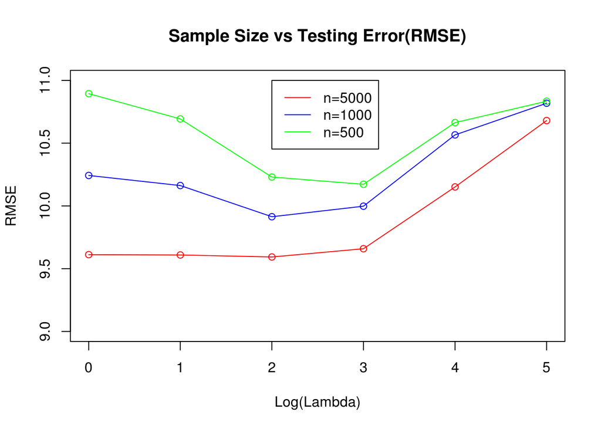

```r
plot(y=testing_error_list, x=log10(lambda_list) ,type = "o",col = "red", xlab = 'Log(Lambda)', ylab = "RMSE", main = 'Sample Size vs Testing Error(RMSE)', ylim=c(9,11))
lines(y=testing_error_list_1000,x=log10(lambda_list), type = "o", col = "blue")
lines(y=testing_error_list_500,x=log10(lambda_list), type = "o", col = "green")
legend(2, 11, legend=c("n=5000", "n=1000", 'n=500'), col=c("red", "blue", "green"),lty=1:1, cex=1)
```

### Insights:

這一題的結果滿漂亮的，可以發現當Lambda 取100~1000之間時，在不同資料量的資料及都有效的製造了testing error的最低點，表示未來如果有同樣的Dataset，可以很有自信的選擇lambda。其中我們也可以看到，資料量越大，Error越低，而且低滿多的，告訴我們更多資料及能提供更好的預測模型。另外、在資料量較少時，lambda的選擇有較大的影響，也可以明顯看到一個U型的曲線。

## Problem (4)

```r
msong_train_1000 = head(msong_train, 1000)
x_train_u1000 = as.matrix(msong_train_1000[,-1])
y_train_1000 = scale(msong_train_1000[,1], scale = FALSE)

x_test_u = msong_test[,-1]
y_test_u = y_test # year - mean(y_train)

# training and recording results
lambda_list = c(1,10,100,1000,10000,100000,1000000,10000000)
scaled_testing_error = c()
scaled_training_error = c()
unscaled_testing_error = c()
unscaled_training_error = c()
for(l in lambda_list){
  result_scaled = train_and_test(x_train_1000,  y_train_1000, x_test, y_test, lambda=l)
  result_unscaled = train_and_test(x_train_u1000, y_train_1000, x_test_u, y_test_u, lambda=l)

  scaled_testing_error = append(scaled_testing_error,result_scaled$testing_error)
  scaled_training_error = append(scaled_training_error, result_scaled$training_error)
  unscaled_testing_error = append(unscaled_testing_error,result_unscaled$testing_error)
  unscaled_training_error = append(unscaled_training_error, result_unscaled$training_error)
}
```

### Visualization

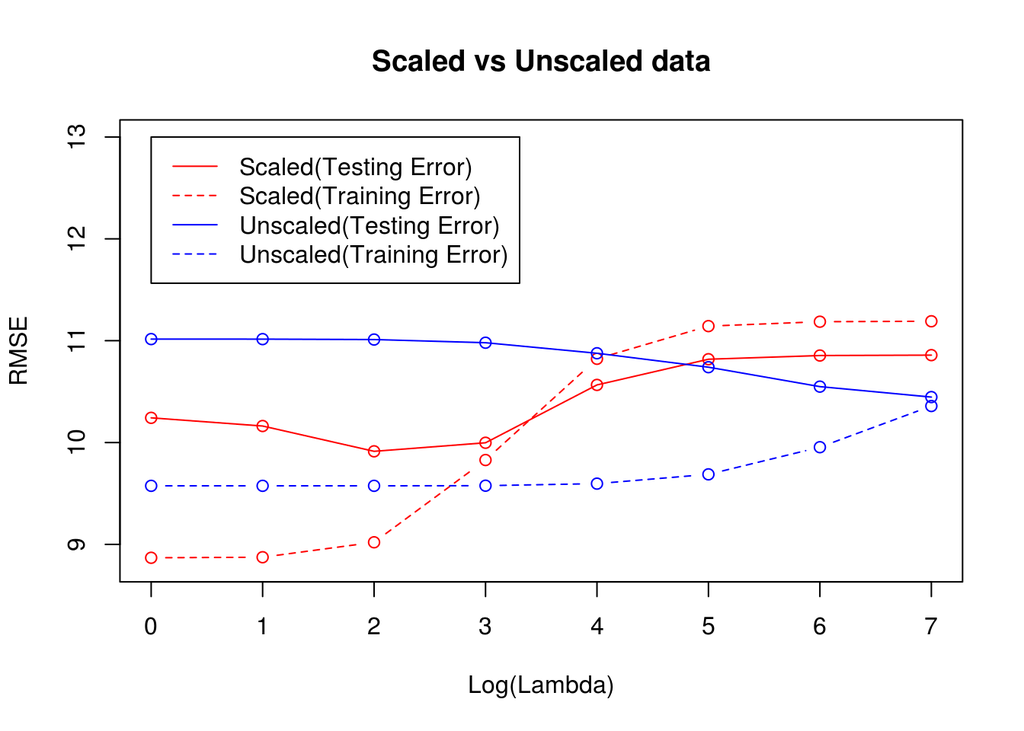

```r
plot(y=scaled_testing_error, x=log10(lambda_list) ,type = "o",col = "red", xlab = 'Log(Lambda)', ylab = "RMSE", main = 'Scaled vs Unscaled data', ylim=c(8.8,13))
lines(y=scaled_training_error,x=log10(lambda_list), type = "b", col = "red", lty=2)

lines(y=unscaled_testing_error,x=log10(lambda_list), type = "o", col = "blue")
lines(y=unscaled_training_error,x=log10(lambda_list), type = "b", col = "blue",lty=2)
legend(0, 13, legend=c("Scaled(Testing Error)", "Scaled(Training Error)", 'Unscaled(Testing Error)','Unscaled(Training Error)'), col=c("red","red", "blue", "blue"),lty=1:2, cex=1)
```

### Insights

這一題由於y都是經過標準化的，我們可以透過testing error來比較何者的預測果較佳。從圖中可以看出，有將features標準化過的(紅線)，在 `lambda = 10^2`時有最好的預測效果，而且Testing Error 低於沒有標準化過(藍線)的最低點，代表有經過標準化能夠提供叫精準的預測。至於沒有經過標準化的Feature set，則是在Lambda = 10^7時有較低的Testing Error，這是因為沒有標準差的X相乘之後會得到一個數值非常大的矩陣，因此加上`lambda*I`的這個調整值也必須較大，才能造成影響，前面lambda < 10000對於數值這麼大的矩陣而言幾乎是沒有作用的。 我們可以推論，經過標準化的feature能帶來較好的結果，也可以很好的控制選擇lambda的範圍。

## Problem(5)

```r
msong_train_1000 = head(msong_train, 1000)
x_train_u1000 = as.matrix(msong_train_1000[,-1])
y_train_u1000 = as.matrix(msong_train_1000[,1])

x_test_u = as.matrix(msong_test[,-1])
y_test_u = as.matrix(msong_test[,1])

lambda_list = c(1,10,100,1000,10000,100000,1000000)
total_mess_training_error = c()
total_mess_testing_error = c()
addition_testing = c()
addition_training= c()
for(l in lambda_list){
  result_new = train_and_test(x_train_u1000,  y_train_u1000, x_test_u, y_test_u, lambda=l)
  result_addition = train_and_test(x_train_1000, y_train_u1000, x_test, y_test_u, lambda = l)

  total_mess_training_error = append(total_mess_training_error, result_new$training_error)
  total_mess_testing_error = append(total_mess_testing_error, result_new$testing_error)
  addition_testing = append(addition_testing, result_addition$testing_error)
  addition_training = append(addition_training, result_addition$training_error)
}
# Two arrays from previous section
# scaled_testing_error
# unscaled_testing_error
```

### Visualization

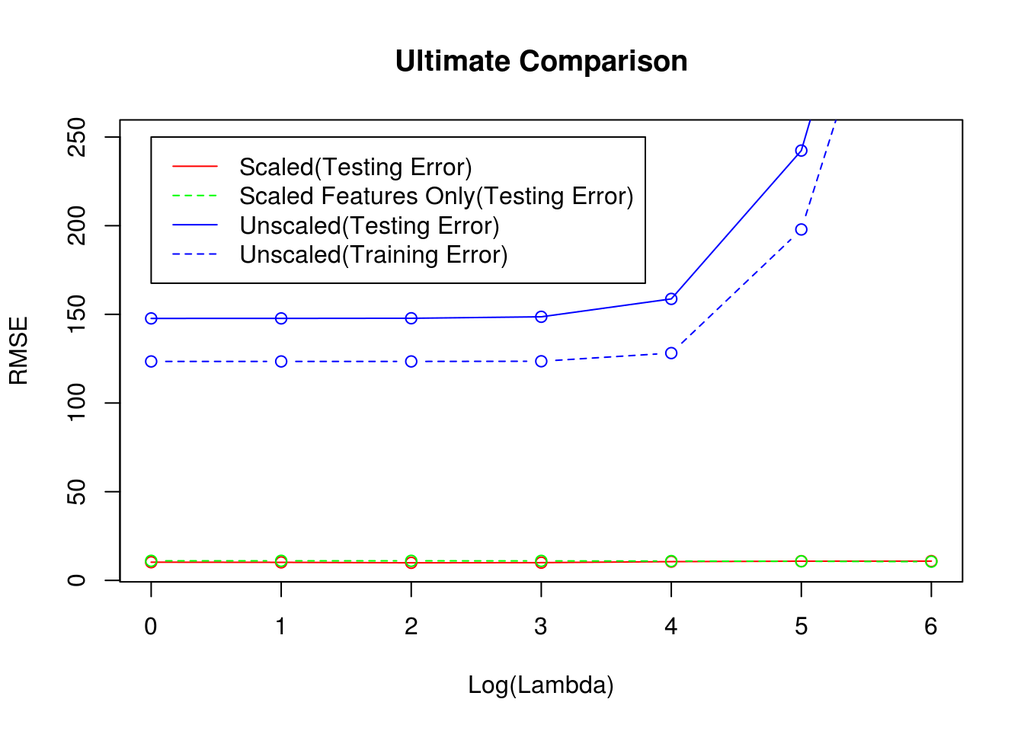

```r
plot(y=scaled_testing_error[1:length(lambda_list)], x=log10(lambda_list) ,type = "o",col = "red", xlab = 'Log(Lambda)', ylab = "RMSE", main = 'Ultimate Comparison', ylim=c(8.8,250))
lines(y=unscaled_testing_error[1:length(lambda_list)],x=log10(lambda_list), type = "b", col = "green", lty=2)
lines(y=total_mess_testing_error,x=log10(lambda_list), type = "o", col = "blue")
lines(y=total_mess_training_error,x=log10(lambda_list), type = "b", col = "blue",lty=2)
legend(0, 250, legend=c("Scaled(Testing Error)", "Scaled Features Only(Testing Error)", 'Unscaled(Testing Error)','Unscaled(Training Error)'), col=c("red","green", "blue", "blue"),lty=1:2, cex=1)
```

### Insights

這一題中我們可以看到，X跟y都沒有經過標準化的藍線，RMSE明顯較大。但我們不能直接比較此題的RMSE以及前面兩題的RMSE，因為這兩組的y並不相同，所以直接比較RMSE是沒有意義的，我們只能觀察出，在沒有經過標準化的這個資料集中，Lambda幾乎沒有幫助，只有在lambda太大時讓Model爛掉而已。

為了要觀察沒有變動Y時的模型特性，我多做了以下的實驗：我做了不變動Y，但是將它的Features X全部標準化的實驗：

### Additional Comparison

[figure not shown]

```r
plot(y=addition_testing, x=log10(lambda_list) ,type = "o",col = "red", xlab = 'Log(Lambda)', ylab = "RMSE", main = 'Additional Comparison', ylim=c(100,2200))
lines(y=addition_training,x=log10(lambda_list), type = "o", col = "red",lty=2)

lines(y=total_mess_testing_error,x=log10(lambda_list), type = "o", col = "blue")
lines(y=total_mess_training_error,x=log10(lambda_list), type = "b", col = "blue",lty=2)

legend(0, 1600, legend=c("Scaled X (Testing Error)", "Scaled X (Training Error)","Original X (Training Error)", "Original X (Testing Error)"), col=c("red","red","blue","blue"),lty=1:2, cex=1)
```

結果可以發現RMSE爆高，這告訴我們在如果我們讓Y維持沒有平移過，但是對X進行標準化，只會造成很小的x數值，無法表達未標準化的Y之間的微小差距。 整體而言，不對y進行平移&標準化的話，由於y都非常接近，會讓預測難度提昇許多。